# CaseStudy4-Analytics With R

Harmandeep Singh

28 November 2017

### **Case Study 4 - Analtytics with R**

#### **Problem - 1** : A physician is evaluating a new diet for her patients with a family history of heart disease. To test the effectiveness of this diet, 16 patients are placed on the diet for 6 months. Their weights and triglyceride levels are measured before and after the study, and the physician wants to know if either set of measurements has changed.

#### **Solution** : Paired Sample T-Test : tg0 - tg4 and wt0 - wt4

```
##   patid age gender tg0 tg1 tg2 tg3 tg4 wgt0 wgt1 wgt2 wgt3 wgt4
## 1     1  45   Male 180 148 106 113 100  198  196  193  188  192
## 2     2  56   Male 139  94 119  75  92  237  233  232  228  225
## 3     3  50   Male 152 185  86 149 118  233  231  229  228  226
## 4     4  46 Female 112 145 136 149  82  179  181  177  174  172
## 5     5  64   Male 156 104 157  79  97  219  217  215  213  214
## 6     6  49 Female 167 138  88 107 171  169  166  165  162  161
```

*Hypothesis*  
Ho : There is no difference between the Pre and Post measurements.  
Ha : There is difference between the Pre and Post measurements.

```r
# triglyceride levels
t.test(dietStudy$tg0,dietStudy$tg4,paired = TRUE)
```

```
##
##  Paired t-test
##
## data:  dietStudy$tg0 and dietStudy$tg4
## t = 1.2, df = 15, p-value = 0.2487
## alternative hypothesis: true difference in means is not equal to 0
## 95 percent confidence interval:
##  -10.91541  39.04041
## sample estimates:
## mean of the differences
##                 14.0625
```

#### **Conclusion**

P-Value = 0.2487 > 0.05  
Therefore, at 95% confidence level we can say that the diet paln doesn’t help to reduce the triglyceride levels of the patient

```r
# Weights
t.test(dietStudy$wgt0,dietStudy$wgt4,paired = TRUE)
```

```
##
##  Paired t-test
##
## data:  dietStudy$wgt0 and dietStudy$wgt4
## t = 11.175, df = 15, p-value = 1.138e-08
## alternative hypothesis: true difference in means is not equal to 0
## 95 percent confidence interval:
##  6.524643 9.600357
## sample estimates:
## mean of the differences
##                  8.0625
```

#### **Problem-2** : An analyst at a department store wants to evaluate a recent credit card promotion. To this end, 500 cardholders were randomly selected. Half received an ad promoting a reduced interest rate on purchases made over the next three months, and half received a standard seasonal ad. Is the promotion effective to increase sales?

```
##     id        insert  dollars
## 1  148      Standard 2232.772
## 2  572 New Promotion 1403.808
## 3  973      Standard 2327.092
## 4 1096      Standard 1280.031
## 5 1541 New Promotion 1513.563
## 6 1947 New Promotion 1729.628
```

#### **Solution** : Independent Group Test :New Promotion ad vs Standard Seasonal ad

*Hypothesis*  
Ho : There is no effect of New Promotion ad.  
Ha : There is effect of New Promotion ad.

```r
t.test(dollars ~ insert,data = creditpromo)
```

```
##
##  Welch Two Sample t-test
##
## data:  dollars by insert
## t = 2.2604, df = 497.6, p-value = 0.02423
## alternative hypothesis: true difference in means is not equal to 0
## 95 percent confidence interval:
##    9.301833 132.920071
## sample estimates:
## mean in group New Promotion      mean in group Standard
##                    1637.500                    1566.389
```

#### **Conclusion**

P-value = 0.02423 < 0.05  
Therefore, at 95% confidence interval we can say that New Promotion has increased the overall sales.

Average Sales in New Promotion ad : 1637.5  
Average Sales in Standard Seasonal ad : 1566.389

#### **Problem-3** : An experiment is conducted to study the hybrid seed production of bottle gourd under open field conditions. The main aim of the investigation is to compare natural pollination and hand pollination. The data are collected on 10 randomly selected plants from each of natural pollination and hand pollination. The data are collected on fruit weight (kg), seed yield/plant (g) and seedling length (cm). (Data set: pollination.csv)

1. Is the overall population of Seed yield/plant (g) equals to 200?
2. Test whether the natural pollination and hand pollination under open field conditions are equally effective or are significantly different.
3. Test whether hand pollination is better alternative in comparison to natural pollination.

```
##     Group Fruit_Wt Seed_Yield_Plant Seedling_length
## 1 Natural     1.85           147.70           16.86
## 2 Natural     1.86           136.86           16.77
## 3 Natural     1.83           149.97           16.35
## 4 Natural     1.89           172.33           18.26
## 5 Natural     1.80           144.46           17.90
## 6 Natural     1.88           138.30           16.95
```

#### **Solution**:

*a. Is the overall population of Seed yield/plant (g) equals to 200?*

*Hytpothesis*  
Ho : Overall population of Seed yield/plant = 200  
Ha : Overall population of seed yield/plant <> 200

```r
t.test(pollination$Seed_Yield_Plant,mu=200)
```

```
##
##  One Sample t-test
##
## data:  pollination$Seed_Yield_Plant
## t = -2.3009, df = 19, p-value = 0.03289
## alternative hypothesis: true mean is not equal to 200
## 95 percent confidence interval:
##  163.3414 198.2656
## sample estimates:
## mean of x
##  180.8035
```

#### **Conclusion**

P-value = 0.03289 < 0.05  
Therefore, we can reject null hypothesis.  
At 95% confidence interval we can say that the overall population of seed yield/plant is not equal to 200.  
Mean of Seed yield/plant = 180.8035

*b. Test whether the natural pollination and hand pollination under open field conditions are equally effective or are significantly different.*

*Hypothesis*  
Ho : Natural Pollination and Hand Polliation is equally effective  
Ha : Natural Pollination and Hand Polliation is significantly different

```r
t.test(Fruit_Wt ~ Group,data = pollination)
```

```
##
##  Welch Two Sample t-test
##
## data:  Fruit_Wt by Group
## t = 17.67, df = 10.397, p-value = 4.307e-09
## alternative hypothesis: true difference in means is not equal to 0
## 95 percent confidence interval:
##  0.6279281 0.8080719
## sample estimates:
##    mean in group Hand mean in group Natural
##                 2.566                 1.848
```

```r
t.test(Seed_Yield_Plant ~ Group,data = pollination)
```

```
##
##  Welch Two Sample t-test
##
## data:  Seed_Yield_Plant by Group
## t = 13.958, df = 17.771, p-value = 5.136e-11
## alternative hypothesis: true difference in means is not equal to 0
## 95 percent confidence interval:
##  59.10515 80.07285
## sample estimates:
##    mean in group Hand mean in group Natural
##               215.598               146.009
```

```r
t.test(Seedling_length ~ Group,data = pollination)
```

```
##
##  Welch Two Sample t-test
##
## data:  Seedling_length by Group
## t = 2.5422, df = 16.43, p-value = 0.02143
## alternative hypothesis: true difference in means is not equal to 0
## 95 percent confidence interval:
##  0.1482489 1.6177511
## sample estimates:
##    mean in group Hand mean in group Natural
##                18.590                17.707
```

#### **Conclusion**

[output not shown]

From the above statistic we can say that the Natural Pollination is significantly different from the Hand pollination.

*c. Test whether hand pollination is better alternative in comparison to natural pollination.*

**From the above statisics we can say that Hand Pollination is better than Natural Pollination.**

#### **Problem:4**: An electronics firm is developing a new DVD player in response to customer requests. Using a prototype, the marketing team has collected focus data for different age groups viz. Under 25; 25-34; 35-44; 45-54; 55-64; 65 and above. Do you think that consumers of various ages rated the design differently?

```
##      agegroup dvdscore
## 1 65 and over 38.45480
## 2       55-64 17.66968
## 3 65 and over 31.70431
## 4 65 and over 25.92446
## 5    Under 25 30.45001
## 6    Under 25 35.60991
```

#### **Solution**: Anova Statistics

*Hypothesis*  
Ho : Consumers of various ages rated the design equally  
Ha : Consumers of various ages rated the design differently

```r
Anova_Segment <- aov(dvdscore ~ agegroup,data = dvdplayer)
summary(Anova_Segment)
```

```
##             Df Sum Sq Mean Sq F value   Pr(>F)
## agegroup     5   1294  258.90   6.993 3.09e-05 ***
## Residuals   62   2296   37.02
## ---
## Signif. codes:  0 '***' 0.001 '**' 0.01 '*' 0.05 '.' 0.1 ' ' 1
```

#### **Conclusion**

P Value = 0.0000309 < 0.05  
At 95% confidence level we can reject the Null hypothesis

#### **Problem-5**:A trial was designed to evaluate 15 rice varieties grown in soil with a toxic level of iron. Guard rows of a susceptible check variety were planted on two sides of each experimental plot. Scores for tolerance for iron toxicity were collected from each experimental plot as well as from guard rows. Data on the tolerance score of each variety and on the score of the corresponding susceptible check are captured. (Data set: tolerance.csv).

1. Are all the varieties having same tolerance?
2. What difference in result you are observing after using susceptible check as covariates in the analysis

#### **Solution**:

*Hypothesis*  
Ho : All varieties have same tolerance level  
Ha : All varieties not have same tolerance level

```r
AOV <- aov(Tol_Score ~ Variety,data=tolerance)

summary(AOV)
```

```
##             Df Sum Sq Mean Sq F value Pr(>F)
## Variety     14  265.9   18.99   0.927  0.543
## Residuals   30  614.7   20.49
```

#### **Conclusion**

From the above test P-Value > 0.05.  
Therefore, we cannot reject the Null Hypothesis.

#### **Problem-6**:A survey was conducted among 2800 customers on several demographic characteristics. Working status, sex, age, age-group, race, happiness, no. of child, marital status, educational qualifications, income group etc. had been captured for that purpose. (Data set: sample_survey.csv).

1. Is there any relationship in between labour force status with marital status?
2. Do you think educational qualification is somehow controlling the marital status?
3. Is happiness is driven by earnings or marital status?

*a. Is there any relationship in between labour force status with marital status?*

```r
chisq.test(survey$wrkstat,survey$marital)
```

```
##
##  Pearson's Chi-squared test
##
## data:  survey$wrkstat and survey$marital
## X-squared = 729.24, df = 28, p-value < 2.2e-16
```

```r
xtabs(~wrkstat + marital,data = survey)
```

```
##                          marital
## wrkstat                   Divorced Married Never married Separated Widowed
##   Keeping house                 25     200            35        13      55
##   Other                         12      16            14         4       8
##   Retired                       53     168            17         6     150
##   School                         7       9            60         2       1
##   Temporarily not working        9      23            11         1       2
##   Unemployed, laid off          10      13            32         0       3
##   Working full time            295     778           392        58      44
##   Working part-time             35     138           102         9      20
```

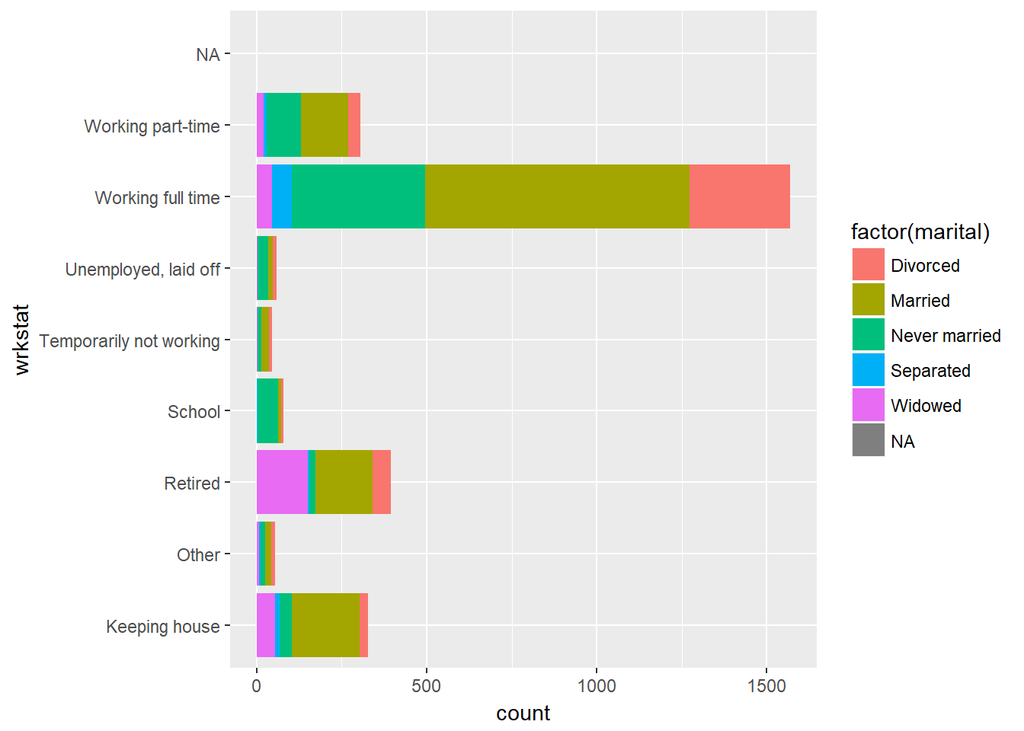

#### **Conclusion**

The above chart shows maximum number of people working full time are Married or Divorced or Never Married

*b. Do you think educational qualification is somehow controlling the marital status?*  
*Hypothesis*  
Ho : There is no relationship between education qualification and marital status  
Ha : There is relationship between education qualification and marital status

```r
chisq.test(survey$educ,survey$marital)
```

```
##
##  Pearson's Chi-squared test
##
## data:  survey$educ and survey$marital
## X-squared = 221.11, df = 76, p-value = 4.31e-16
```

```r
xtabs(~educ + marital,data = survey)
```

```
##     marital
## educ Divorced Married Never married Separated Widowed
##   0         0       1             1         0       0
##   2         0       1             1         0       3
##   3         2       3             2         1       2
##   4         2       2             1         0       4
##   5         2       3             0         0       3
##   6         2      12             2         1       6
##   7         6      11             0         0       4
##   8         9      36             8         2      27
##   9        18      28             9         4      16
##   10       26      48            21         3      15
##   11       25      50            40         6      17
##   12      125     415           180        33      98
##   13       48     118            71        16      17
##   14       62     168            89         9      21
##   15       26      56            48         3      13
##   16       47     214           116        10      25
##   17       13      46            24         2       1
##   18       12      66            24         1       6
##   19        9      21             8         1       2
##   20       10      40            15         1       3
```

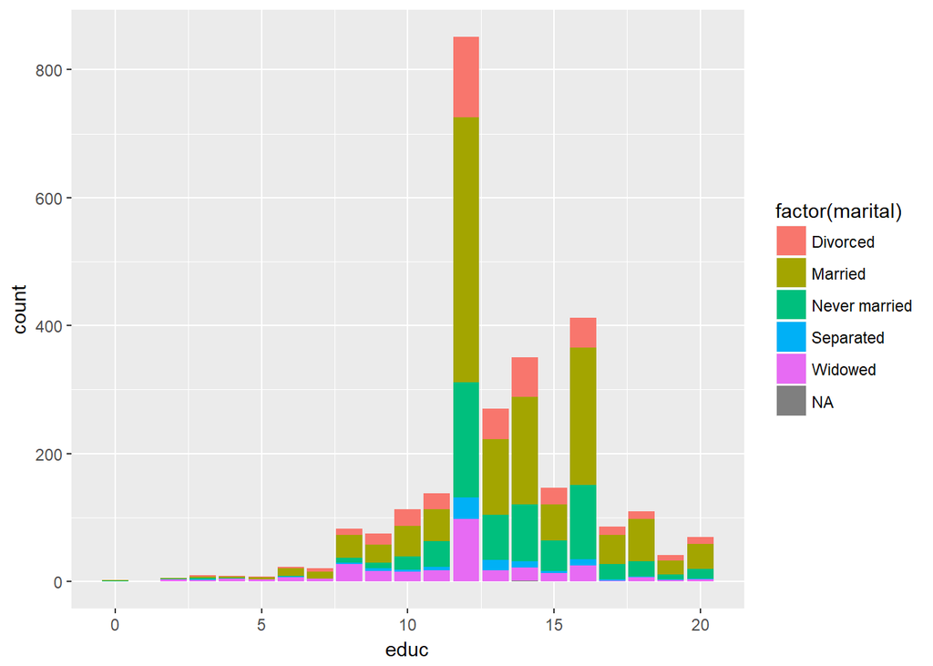

#### **Conclusion**

From the above statistics P-Value is less than 0.05. Therefore, we can reject null hypothesis.  
The above statistics shows that most of the married people lies within 12-16 education level.

*c. Is happiness is driven by earnings or marital status?*

```r
chisq.test(survey$marital,survey$happy)
```

```
##
##  Pearson's Chi-squared test
##
## data:  survey$marital and survey$happy
## X-squared = 260.69, df = 8, p-value < 2.2e-16
```

```r
xtabs(~happy + marital,data = survey)
```

```
##                marital
## happy           Divorced Married Never married Separated Widowed
##   Not too happy       72      71           108        30      59
##   Pretty happy       278     684           426        49     137
##   Very happy          93     582           120        13      83
```

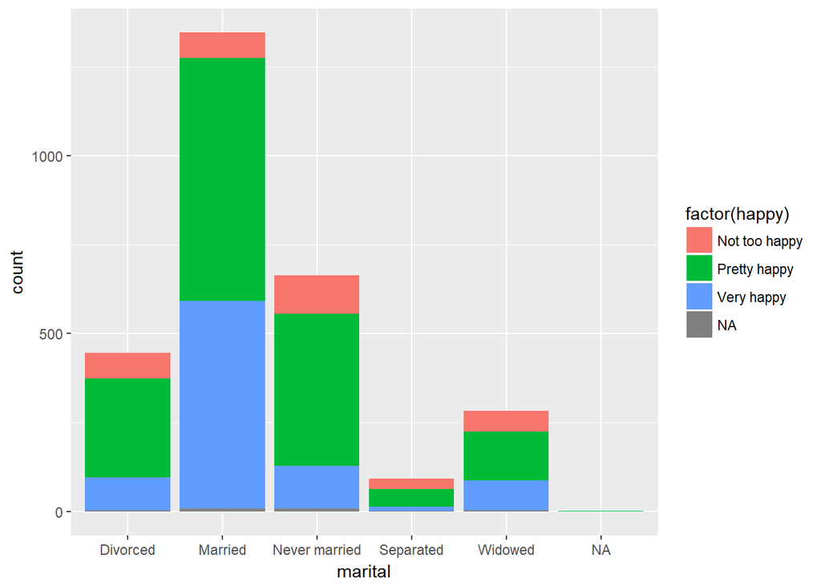

```r
chisq.test(survey$income,survey$happy)
```

```
##
##  Pearson's Chi-squared test
##
## data:  survey$income and survey$happy
## X-squared = 178.95, df = 22, p-value < 2.2e-16
```

```r
xtabs(~income + happy,data = survey)
```

```
##                 happy
## income           Not too happy Pretty happy Very happy
##   $1000 TO 2999              7           20          5
##   $10000 - 14999            39          107         44
##   $15000 - 19999            33          119         26
##   $20000 - 24999            40          155         50
##   $25000 or more           113          888        571
##   $3000 TO 3999              9           11          4
##   $4000 TO 4999              9           13         10
##   $5000 TO 5999              6           18         11
##   $6000 TO 6999             14           13          6
##   $7000 TO 7999             12           21         14
##   $8000 TO 9999              9           30         19
##   LT $1000                  11           13         11
```

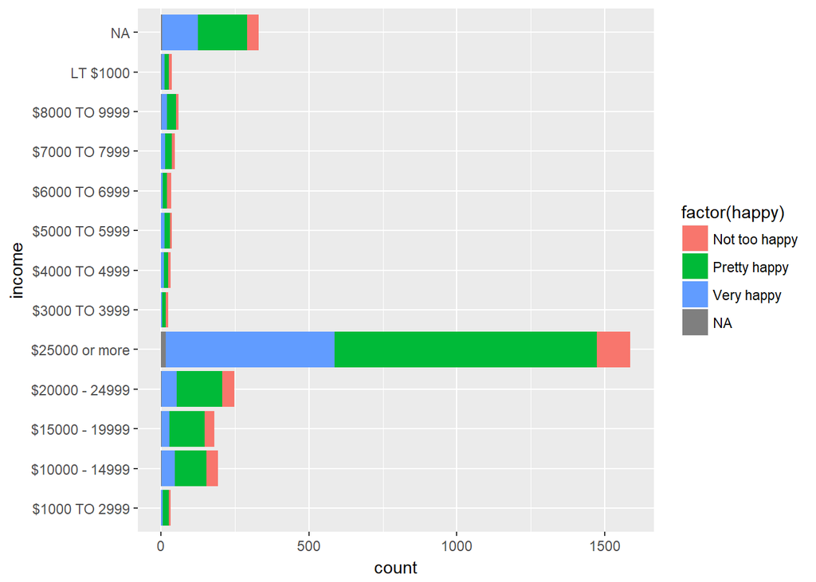

#### **Conclusion**

From the above statistics Married people are more Pretty happy or Very Happy. Also, people with salary greater than equal to $25000 are Very Happy or Pretty Happy.